# Documentacao_campanha

2025-07-23

### Pesquisando dispersão dos retornos de valor produzido

Valor produzido - retorno (%) Para saber se existem diferenças estatisticamente siginificantes nos total produzido por usuário, será feito agrupamento sumarizando total por usuário e serão comparados os valores do mes x com mes x + 1.

A bucar a média de retorno dos últimos 6 meses de alguns parceiros, é possível perceber a grande variância entre eles. Isso é provodado pela grande volatilidade na produção. Se no mês de maio minha produção foi de R$50mil, e, no mês de jungo R$100mil, já são 100% de retorno sobre o mês anterior.

Amostra - tendência de retornos por mês

| ret_fev | ret_mar | ret_abr | ret_mai | ret_jun | mean_var |
| --- | --- | --- | --- | --- | --- |
| -11.21 | 151.30 | -83.34 | 270.31 | -85.74 | 48.264 |
| -30.40 | 275.10 | -33.91 | -44.54 | 73.22 | 47.894 |
| -79.49 | 457.05 | -24.64 | -19.24 | 5.28 | 67.792 |
| 95.34 | -4.08 | -35.74 | -60.68 | 104.79 | 19.926 |
| -51.15 | 308.33 | -77.22 | -2.08 | 73.04 | 50.184 |

Demonstrando crescimento linear e crescimento variante

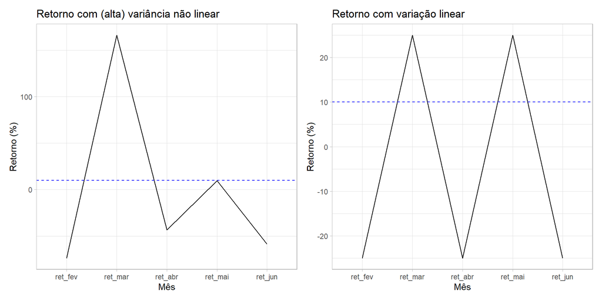

### Explicando a diferença do comportamento dos retornos reais (acima, à esquerda) dos ideais (acima, à direta).

#### Retorno ideal (simulado)

Se os retornos fossem linearmente distribuídos haveria um padrão identificável, permitindo-se traçar parâmetros para a campanha de forma genérica, e, ao mesmo tempo, garantir a mesma probabilidade à grande maioria dos parceiros.

Nestes casos, supondo um retorno médio de 20%, poderia-se afirmar, por exemplo, que:

1 - Em aproximadamente 68,26% dos casos, a média de retorno estaria entre 14% e 26%.

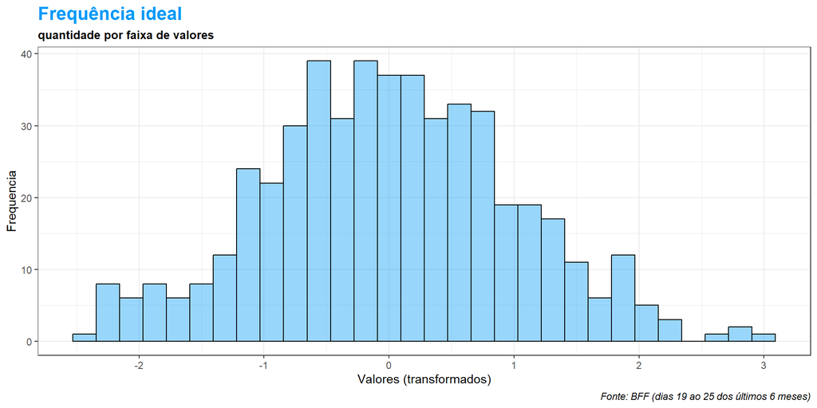

#### Retornos reais

Os retornos reais, contudo, demonstram grande variância (de -90% à 3000%), e retornos não lineares (sem padrão identificável).

Mesmo tratando a não-linearidade, a grande variância dos retornos é um impedimento ainda presente para se fixar um limiar apenas para todos os parceiros.

No caso dos perceiros da v8, mesmo eliminando a falta de padrão, pode-se afirmar, que:

1 - Em aproximadamente 68,26% dos casos, a média de retorno estaria entre 0% e 176.23%.

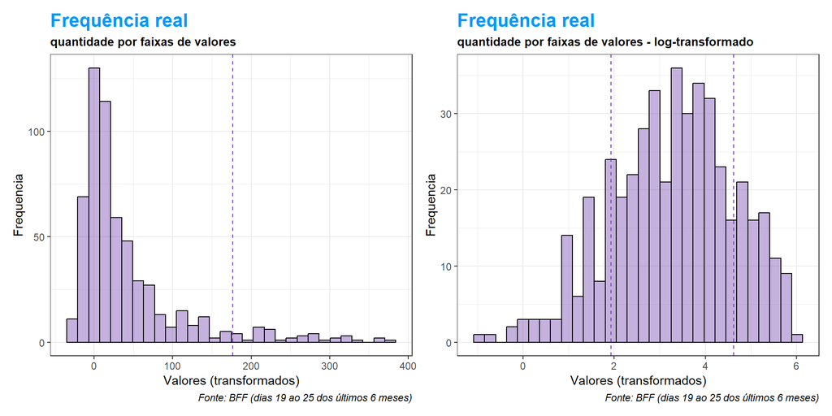

```
## [1] "Em escala real, a média é de  26.5 % e o desvio é de  149.73 %"
```

Conclusões:

A probabilidade associada ao retorno de 10% (ou menor), é muito baixa (cerca de 2.41%) | 97.59% dos retornos serão maiores. A probabilidade associada ao retorno médio (26% ou menor), é de 50% | 50% dos retornos serão maiores. A probabilidade associada ao retorno de 1 desvio (176% ou menor) é de 81.74% | 18.26% dos retornos serão maiores

O que é possível concluir:

2 - Dividir os parceiros em vários grupos, e então calcular as métricas da campanha, pode trazer tantos desafíos da parte operacional que inviabilizará a campanha em diversos aspectos.

Solução: desenhar uma campanha escalonada em valores (absolutos) produção. - A campanha deve ter níveis de valores produzido (como meta) e organizados em escala (do menor para o maio)

- A premiação deverá ser proporcional ao valor da escala (menores valores terão premiação com menor valor)
- As premiações são não-cumulativas.

### Exemplo de campanha

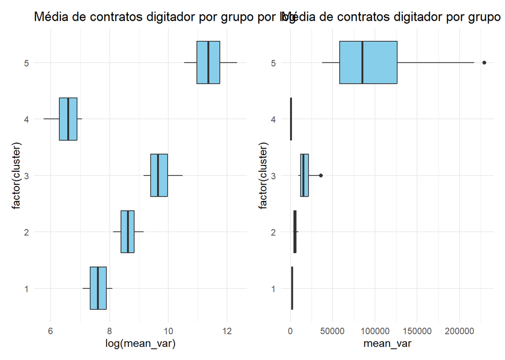

# Existe um grupo, cuja diferença entre os valores são pequenas

## visualizando características dos grupos

Estatísticas por grupo

| cluster | concentracao | mediana | proprocao_grupos |
| --- | --- | --- | --- |
| 5 | 58133.82 - 126408.37 | 84892.65 | 10.20 |
| 3 | 12078.57 - 21471.7 | 15415.61 | 26.53 |
| 2 | 4379.1 - 6834.42 | 5512.98 | 31.80 |
| 1 | 1547.61 - 2658.63 | 1974.11 | 23.64 |
| 4 | 539.13 - 984.45 | 725.91 | 7.82 |

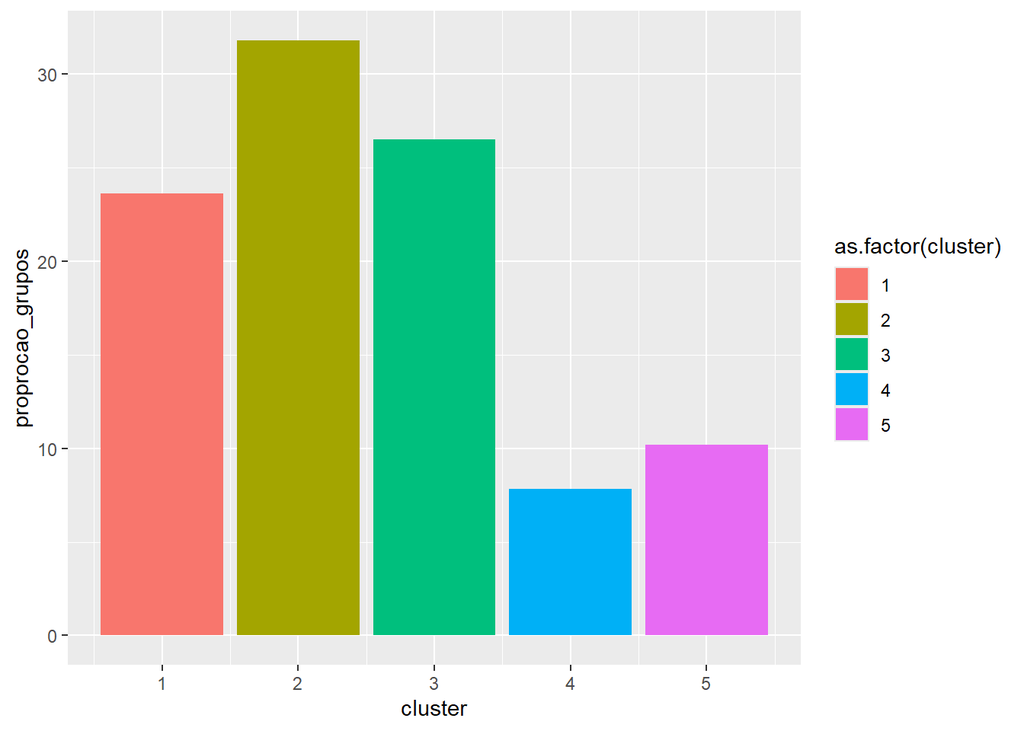

# Definindo faixas

Quanto maiores as faixas de valor, menos parceiros estarão representados. Por exemplo, com base na amostra colhida, o grupo 5 tem a maior faixa de valor (58133.82 - 126408.37), mas, representa apenas 10% dos parceiros.

Assim sendo, a campanha pode ser modelada de acordo com os objetivos, e, observando as características dos parceiros.

Abaixo, sugestão de campanha ficada nos 90% dos parceiros da amostra colhida.

Sugere-se com valores para faixas, o correspondente ao terceiro quartil de cada grupo (.75%).

Assim tempos um valor bastante acessível, e, que, representa um real aumento.

### Faixas:

| Faixa | Valor | Representatividade |
| --- | --- | --- |
| Faixa 1 | R$ 10596.96 | 73,98% |
| Faixa 2 | R$ 27173.08 | 17% |
| Faixa 3 | R$ 130626.53 | 9% |